# **An evalutation of Fighters in the UFC**

To help display these statistics we are going to use a [pairplot](https://www.geeksforgeeks.org/python-seaborn-pairplot-method/). This pairplot is going to compare striking, striking defense, and win percentage. First, we are going to make a striking attribute which multiplies the significant_strikes_landed_per_minute with significant_striking_accuracy / 100. We also need to make a striking defense attribute which multiplies significant_strikes_absorbed_per_minute with significant_strike_defence / 100. These scores will give us an idea of how effective each fighter is at striking and defending. A higher attack score means that the fighter is better at striking and a higher defense score that the fighter takes a lot of hits, so a lower defense score is better.

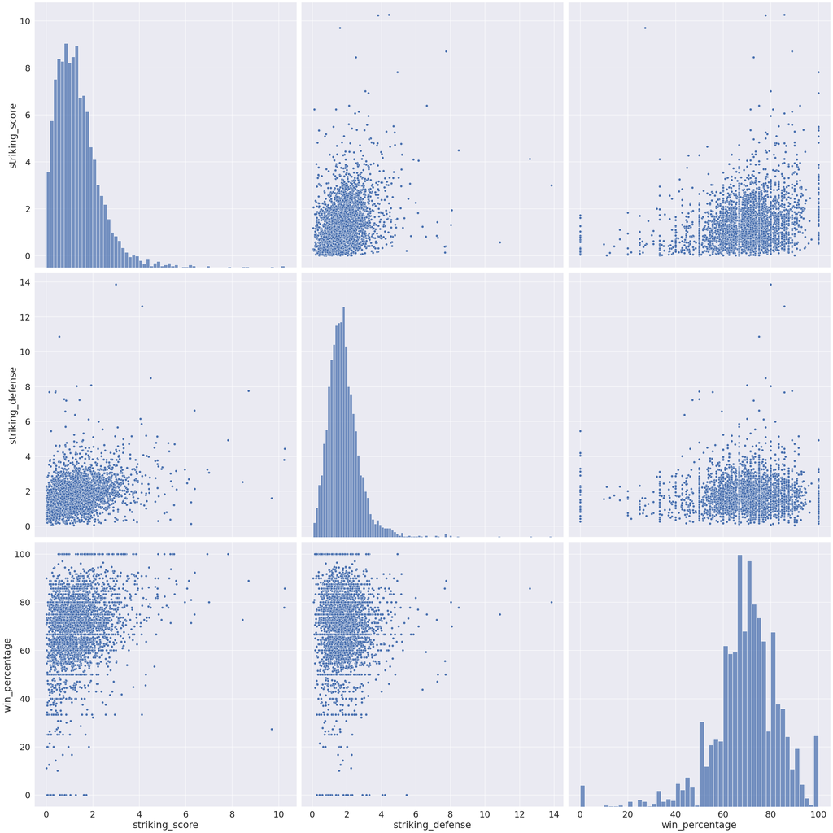

```python
df_strike = df.copy(deep=True)
df_strike = df_strike.loc[(df_strike['significant_strikes_landed_per_minute'] != 0.0) & (df_strike['significant_striking_accuracy'] != 0.0)
                      & (df_strike['significant_strikes_absorbed_per_minute'] != 0.0) & (df_strike['significant_strike_defence'] != 0.0)]
df_strike['striking_score'] = df_strike['significant_strikes_landed_per_minute'] * (df_strike['significant_striking_accuracy'] / 100)
df_strike['striking_defense'] = df_strike['significant_strikes_absorbed_per_minute'] * (df_strike['significant_strike_defence'] / 100)
df_strike = df_strike[['striking_score','striking_defense','win_percentage']]
sns.pairplot(df_strike, height=10);
plt.show()
```

From looking at the pairplot, most of the fighters have an attack stat less than four. For all of those fighters there really is no relationship with win percentage. However, for the fighters with an attack stat higher than four, most of them a high win percentage. For defense, most fighters have a low defense score so it is difficult to tell whether there is a relationship, but there is something I did notice. Majority of the fighters with a 100% win percentage have a defense score less than 2.5 and all have a defense score less than five. This means that all of the fighters who have not lost yet have a very strong striking defense.

While there may not be much relationship between striking and win percentage maybe there is a relationship between takedowns and win percentage. The higher the takedown score and defense means that the fighter is better at taking people down and defending against takedowns. The takedown score is

`df_takedown['takedown_score'] = df_takedown['average_takedowns_landed_per_15_minutes'] * (df_takedown['takedown_accuracy'] / 100)`

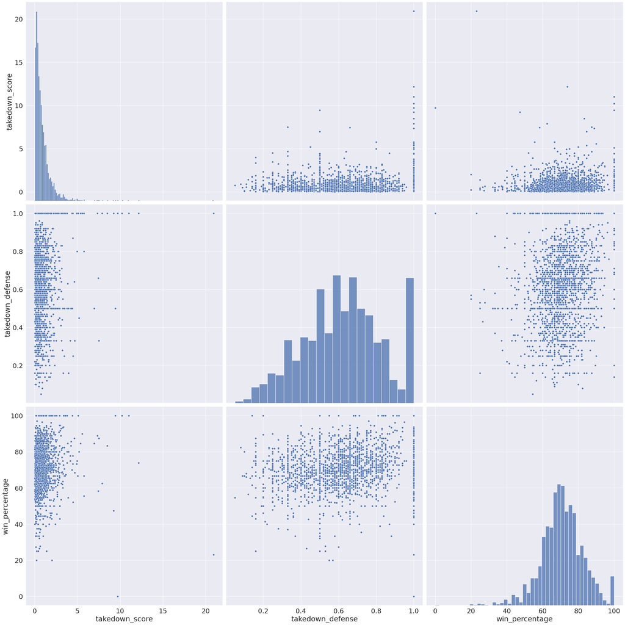

```python
df_takedown = df.copy(deep=True)
df_takedown = df_takedown.loc[(df_takedown['average_takedowns_landed_per_15_minutes'] != 0.0)
                              & (df_takedown['takedown_accuracy'] != 0.0) & (df_takedown['takedown_defense'] != 0.0)]
df_takedown['takedown_score'] = df_takedown['average_takedowns_landed_per_15_minutes'] * (df_takedown['takedown_accuracy'] / 100)
df_takedown['takedown_defense'] = df_takedown['takedown_defense'] / 100
df_takedown = df_takedown[['takedown_score','takedown_defense','win_percentage']]
sns.pairplot(df_takedown, height=10);
plt.show()
```

The data in the pairplot does not really show any relationship between takedowns and win percentage. A few things I did notice were that there was a fighter with a takedown score greater than 20 and their win percentage was barely above 20%. There was another fighter with a takedown defense of 1, but their win percentage was 0%. While they are only two fighters, this shows that just because a fighter is really good at taking thier opponent down and defending against takedowns that they will not necessarily be more likely to win.

While takedowns and striking are very important, submissions are what actually win a fight if it does not go all of the rounds. Lets see if there is a relationship between submissions and win percentage.

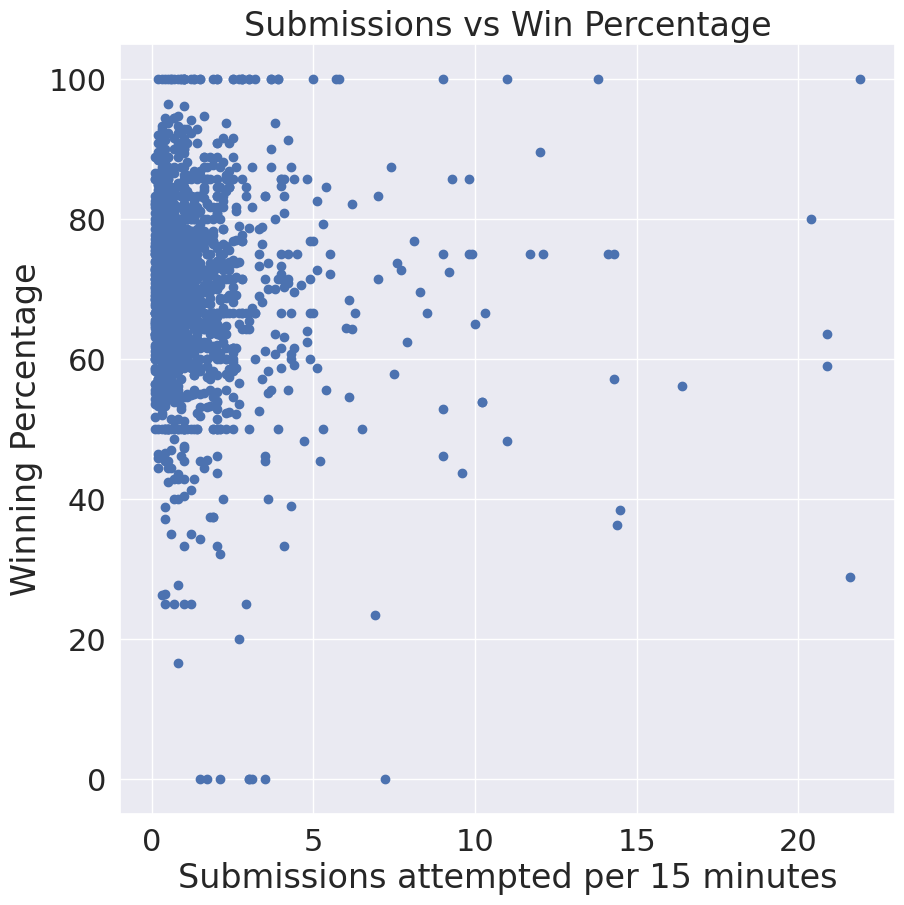

```python
fig = plt.figure(figsize = (10, 10))
df_submit = df.copy(deep=True)
df_submit = df_submit.loc[df_submit['average_submissions_attempted_per_15_minutes'] != 0.0]
plt.scatter(df_submit['average_submissions_attempted_per_15_minutes'], df_submit['win_percentage'])
plt.title(f"Submissions vs Win Percentage")
plt.xlabel('Submissions attempted per 15 minutes')
plt.ylabel('Winning Percentage')
plt.grid(True)
plt.show()
```

Just like striking and takedowns, there does not seem to be any relationship between submissions and win percentage. I beleive that there is no relationship between striking, takedowns, and submissions because there are so many different fighting styles. Some fighters are mainly strikers who do not grapple and take fighters down while other fighters prefer the ground game and do not strike their opponents very often or very well.

**Model: Analysis, Hypothesis Testing, Machine Learning**

In this section of the tutorial we will be implementing modeling techniques in order to predict the win percentage of UFC fighters based on statistics such as height, weight, reach, striking accuracy, etc.

```python
features = ['height_ft', 'weight_lb', 'reach_ft', 'age',
            'significant_strikes_landed_per_minute', 'significant_striking_accuracy',
            'significant_strikes_absorbed_per_minute', 'significant_strike_defence']
x = df[features]
y = df["win_percentage"]

df_clean = df.dropna(subset=features)
x_clean = df_clean[features]
y_clean = df_clean["win_percentage"]

x_train, x_test, y_train, y_test = train_test_split(x_clean, y_clean, test_size=0.05)

model = LinearRegression()

model.fit(x_train, y_train)

y_pred = model.predict(x_test)

for pred, actual in zip(y_pred, y_test):
    print("Predicted: {:.2f}, Actual: {:.2f}".format(pred, actual))
```

```
Predicted: 65.29, Actual: 72.92
Predicted: 81.74, Actual: 88.89
Predicted: 74.81, Actual: 75.00
Predicted: 70.04, Actual: 66.67
Predicted: 81.04, Actual: 87.50
Predicted: 69.29, Actual: 75.00
Predicted: 64.35, Actual: 78.57
Predicted: 72.29, Actual: 75.00
Predicted: 69.97, Actual: 50.00
Predicted: 75.05, Actual: 75.00
Predicted: 71.16, Actual: 59.57
Predicted: 64.87, Actual: 50.00
Predicted: 73.32, Actual: 62.50
Predicted: 77.96, Actual: 100.00
Predicted: 75.18, Actual: 69.23
Predicted: 71.83, Actual: 67.31
Predicted: 78.04, Actual: 75.00
Predicted: 80.82, Actual: 80.00
Predicted: 81.42, Actual: 72.73
Predicted: 62.94, Actual: 54.69
Predicted: 72.94, Actual: 72.22
Predicted: 77.63, Actual: 100.00
Predicted: 75.78, Actual: 76.47
Predicted: 84.39, Actual: 87.50
Predicted: 72.65, Actual: 70.00
Predicted: 76.00, Actual: 83.33
Predicted: 68.11, Actual: 81.25
Predicted: 79.01, Actual: 87.50
Predicted: 79.00, Actual: 66.67
Predicted: 74.64, Actual: 68.42
Predicted: 75.66, Actual: 60.87
Predicted: 71.89, Actual: 81.82
Predicted: 70.54, Actual: 68.42
Predicted: 68.21, Actual: 75.00
Predicted: 85.17, Actual: 72.73
Predicted: 74.32, Actual: 65.00
Predicted: 69.17, Actual: 70.73
Predicted: 79.86, Actual: 62.50
Predicted: 63.28, Actual: 68.42
Predicted: 73.26, Actual: 72.73
```

[output cut: 54 more lines]

```
Predicted: 72.14, Actual: 72.73
Predicted: 82.05, Actual: 65.52
Predicted: 74.75, Actual: 80.00
Predicted: 64.56, Actual: 57.89
Predicted: 74.56, Actual: 68.75
Predicted: 68.55, Actual: 59.65
Predicted: 65.82, Actual: 71.43
Predicted: 78.92, Actual: 83.33
Predicted: 64.25, Actual: 72.34
Predicted: 72.61, Actual: 66.67
Predicted: 83.87, Actual: 72.73
Predicted: 74.10, Actual: 58.82
Predicted: 66.87, Actual: 84.62
Predicted: 78.61, Actual: 76.92
Predicted: 68.22, Actual: 66.67
```

The predicitions are typically relatively close.The results are typically less than 10% off. However it does struggle a little bit when values are outliers.

```python
array = np.array(y_pred)
actual = y_test.values
squared_error = (actual.astype(float) - array) ** 2
mse = np.mean(squared_error)

print("Mean Squared Error:", mse)
```

```
Mean Squared Error: 126.63504333921126
```

As seen the mean squared error is quite large. In order to address this we will use RANSAC regression in order to improve the predictions. We decided to do this becuase RANSAC distinguishes between inliers and outliers in order to reduce bias.

```python
ransac = RANSACRegressor(LinearRegression(), random_state=42)
ransac.fit(x_clean, y_clean)
inlier_mask = ransac.inlier_mask_
outlier_mask = np.logical_not(inlier_mask)

x_inliers = x_clean[inlier_mask]
y_inliers = y_clean[inlier_mask]

x_train, x_test, y_train, y_test = train_test_split(x_inliers, y_inliers, test_size=0.05, random_state=42)

model = LinearRegression()

model.fit(x_train, y_train)

y_pred = model.predict(x_test)

for pred, actual in zip(y_pred, y_test):
    print("Predicted: {:.2f}, Actual: {:.2f}".format(pred, actual))
```

```
Predicted: 70.04, Actual: 67.31
Predicted: 67.09, Actual: 70.00
Predicted: 66.55, Actual: 67.86
Predicted: 66.00, Actual: 72.22
Predicted: 70.17, Actual: 67.65
Predicted: 70.44, Actual: 70.59
Predicted: 77.27, Actual: 75.00
Predicted: 74.04, Actual: 75.00
Predicted: 71.47, Actual: 69.23
Predicted: 75.17, Actual: 71.43
Predicted: 69.29, Actual: 73.91
Predicted: 75.82, Actual: 80.00
Predicted: 74.25, Actual: 73.91
Predicted: 69.33, Actual: 65.38
Predicted: 74.13, Actual: 76.67
Predicted: 73.32, Actual: 66.67
Predicted: 71.76, Actual: 66.67
Predicted: 71.53, Actual: 75.00
Predicted: 71.61, Actual: 65.52
Predicted: 71.78, Actual: 69.23
Predicted: 73.09, Actual: 68.00
Predicted: 73.74, Actual: 76.92
Predicted: 67.22, Actual: 66.67
Predicted: 72.10, Actual: 78.95
Predicted: 74.36, Actual: 75.61
Predicted: 70.45, Actual: 66.67
Predicted: 67.63, Actual: 70.00
Predicted: 71.22, Actual: 64.52
Predicted: 67.85, Actual: 65.00
Predicted: 72.17, Actual: 68.29
Predicted: 67.92, Actual: 63.64
Predicted: 69.90, Actual: 73.91
Predicted: 71.00, Actual: 70.59
Predicted: 68.57, Actual: 72.22
Predicted: 70.94, Actual: 62.50
Predicted: 69.31, Actual: 69.23
Predicted: 64.16, Actual: 66.67
Predicted: 76.02, Actual: 77.78
Predicted: 73.48, Actual: 72.41
Predicted: 71.07, Actual: 67.86
Predicted: 70.64, Actual: 66.67
Predicted: 66.84, Actual: 69.23
Predicted: 76.19, Actual: 77.78
Predicted: 66.92, Actual: 65.00
Predicted: 72.57, Actual: 70.00
Predicted: 71.50, Actual: 66.67
Predicted: 69.68, Actual: 69.05
Predicted: 73.19, Actual: 68.97
Predicted: 77.67, Actual: 73.68
Predicted: 77.02, Actual: 80.00
Predicted: 67.81, Actual: 61.54
```

As can be seen the predictions are all very close. Now lets see what the mean squared error is.

```python
array = np.array(y_pred)
actual = y_test.values
squared_error = (actual.astype(float) - array) ** 2
mse = np.mean(squared_error)

print("Mean Squared Error:", mse)
```

```
Mean Squared Error: 14.259552310177424
```

As can be seen the mean squared error is a lot lower. RANSAC was successfully able to more accurately predict the win percentage for fighters given their stats.

**Insight & Policy Decision**

We hope that this tutorial has helped you develop a better understanding of how to create a model to predict UFC fighters' win percentages. In the realm of sports analytics, the ability to predict the outcome of a fight is invaluable.

If we had more time to conduct further research, we could implement additional models to improve the prediction accuracy of win percentages. Additionally, acquiring more comprehensive data on fighters would enhance our model's ability to make accurate predictions.

We hope that after following this tutorial, you have learned how to build models to predict UFC fighters' win percentages. Improving these models is an ongoing process, and with continuous learning and experimentation, your predictions will become better and more accurate.